# Weekly Energy Charts

January 27, 2023

Sign up to receive our email updates via [Substack](https://leach.substack.com/)

[interactive chart not shown]

# Featured Stories

## Solar vs Coal in Alberta

#### Andrew Leach

Did you ever think you’d see solar supply more electricity than coal in Alberta? In January?

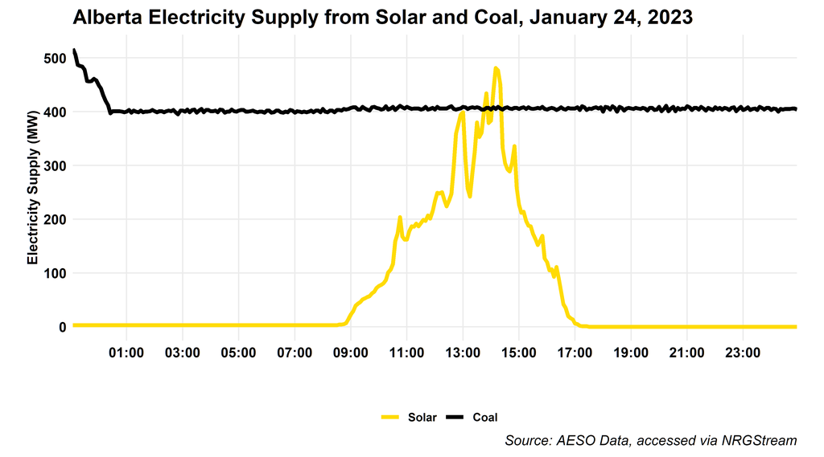

## RBC pressed to cut fossil-fuel financing

#### [Erica Beattie](https://www.linkedin.com/in/erica-beattie-594b471a1/?originalSubdomain=ca)

Shareholders are putting pressure on banks including the Royal Bank of Canada,, JPMorgan Chase & Co., and Citigroup Inc to reduce financing of fossil fuels to meet global climate goals. Banks are being asked by investors to phase out their funding of oil and gas exploration and development, and to oyt forward plans to better align their lending services with climate goals.

Additionally, three New York City pension plans have said that they want lenders, such as RBC, to disclose their 2030 targets to cut greenhouse gas emissions on an absolute basis instead of an intensity basis.

Some progress has been made, but it is not quite enough. For example, banks organized a total of $533 billion of lending for the oil, gas, and coal sectors last year, compared to $656 in 2021. Ultimately, banks are being asked by shareholders to set policies and increase their transparency when it comes to how they are achieving their climate goals.

The investors’ reasoning behind this is that without these policies in place, banks will not be able to meet their own climate targets and risk possible fines from regulators that want to prevent companies from “making exaggerated environmental claims” or *greenwashing*. The idea is to encourage banks to finance companies that are certified to be on a net-zero pathway.

See original article [here](https://financialpost.com/commodities/energy/oil-gas/royal-bank-of-canada-fossil-fuel-financing-carbon-emissions)

## Imperial’s Renewable Diesel

#### Kayla Layden

On Thursday, Imperial Oil announced it had approved $720 million for a new renewable diesel facility at its Strathcona refinery near Edmonton. The project, first announced in August of 2021, will be the largest facility of its kind in Canada. Site preparation and initial construction are currently underway, with production expected to begin in 2025.

Imperial plans to produce 20,000 barrels per day of renewable diesel (more than 1 billion litres per year) from locally sourced vegetable oils, mainly canola and soybean. To create a low-emission fuel, the new facility will also use low-carbon hydrogen obtained via pipeline from [Air Products’ net-zero hydrogen plant](https://www.cbc.ca/news/canada/calgary/bakx-hydrogen-ira-2023-cp-1.6713038) currently under construction in northeast Edmonton. A significant portion of the production will be supplied to British Columbia to support the province’s efforts to lower carbon emissions. Imperial also plans to use some of the renewable diesel in its own operations.

On top of the environmental benefits, Imperial claims that the project will create roughly 600 direct construction jobs.

[Original Article](https://www.cbc.ca/news/canada/calgary/imperial-diesel-renewable-edmonton-1.6726962)

[Imperial Oil’s News Release](https://news.imperialoil.ca/news-releases/news-releases/2023/Imperial-Approves-720-million-for-Largest-Renewable-Diesel-Facility-in-Canada/default.aspx)

## Spending on Clean Energy Matches Fossil Fuels

#### [Marc Vermette](https://www.linkedin.com/in/marc-vermette/)

The world spent $1.1 trillion USD last year replacing fossil fuels - the same amount that was spent producing oil and gas.

Solar and wind power accounted for 45% of this spending, and electric vehicles for 43%.

The 2022 renewable spending was 31% greater than 2021, but still far from what is needed to reach net zero by 2050.

A [study by BloombergNEF](https://about.bnef.com/blog/global-low-carbon-energy-technology-investment-surges-past-1-trillion-for-the-first-time/) shows that annual spending would have to triple from its present all-time high to be able to reach this goal.

As for a win we CAN claim, when we factor in the strengthening of clean energy supply chains, power grids, and financing projects, the global spending on the energy transition exceeds that of oil and gas production by nearly $500 billion.

[Original Article](https://www.bloomberg.com/news/articles/2023-01-26/global-clean-energy-investments-match-fossil-fuel-for-first-time)

## Africa nears gigawatt capacity

#### [Yousaff Habib](https://www.linkedin.com/in/yousaff-habib-6684891a5/)

The AFSIA’s Annual Report 2022, published this week, also highlights that every country on the continent has plans to construct new solar projects in the near future, with 29 countries currently working on at least 100 MW of new installations. AFSIA notes that while these figures may appear small compared to other regions of similar size and population, there are numerous opportunities for the growth of the solar industry in Africa.

The report identifies the commercial and industrial segment as a significant opportunity for solar energy in Africa. Unlike in other regions where companies prioritize cheaper electricity as the primary motivation for investing in C&I solar, companies in Africa are driven by the need for a secure power supply. Across the continent, the C&I market grew by over 60% in 2022, representing 28% of all installations.

Additionally, the report also predicts that green hydrogen projects will drive significant demand for new PV, with 52 GW of new PV in development for projects exclusively using the power to produce hydrogen. Furthermore, the growing trend for electric vehicles is also expected to drive new solar installations across Africa, as many countries will need to double or even triple their electricity generation capacity to meet the demand for EV charging, and solar energy is seen as the most cost-effective and cleanest way to achieve this.

You can learn more about solar power in Africa from the AFSIA website, which can be found [here](http://afsiasolar.com/data-center/reports/). I’d recommend taking a look at the current reports, as well as the 2023 outlook. Africa is ripe for solar investment, and we will likely see major growth there in coming years.

# Oil

## Weekly Crude Prices

### Feature Crude

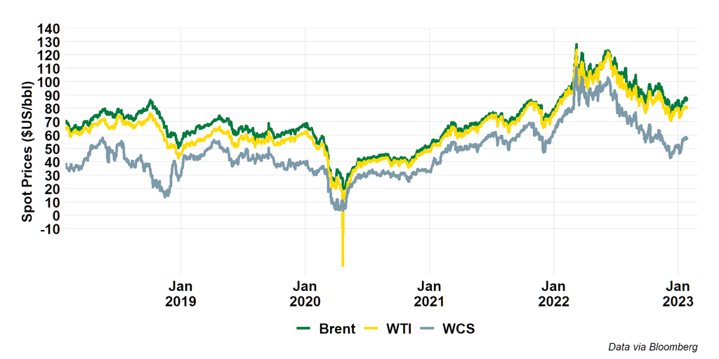

### Alberta Crude

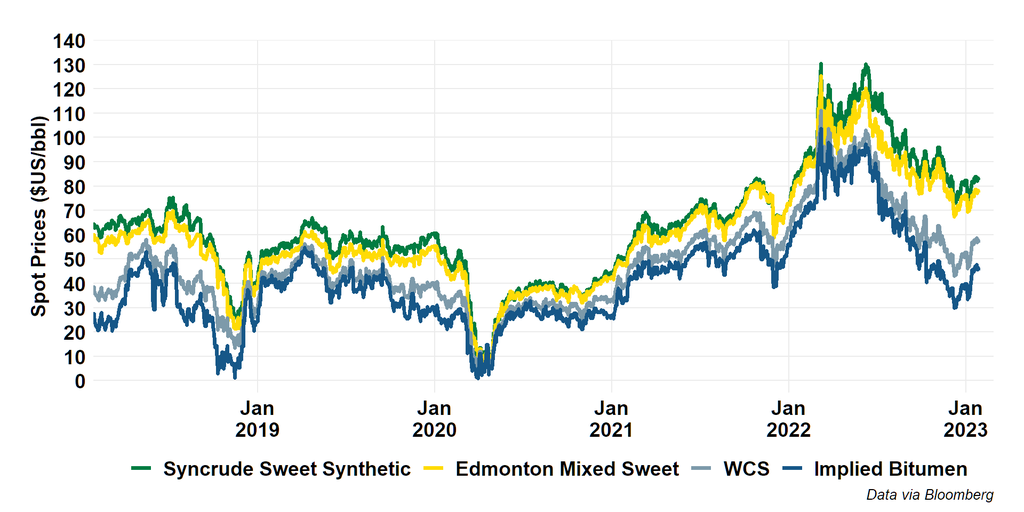

### Alberta Crude (Short)

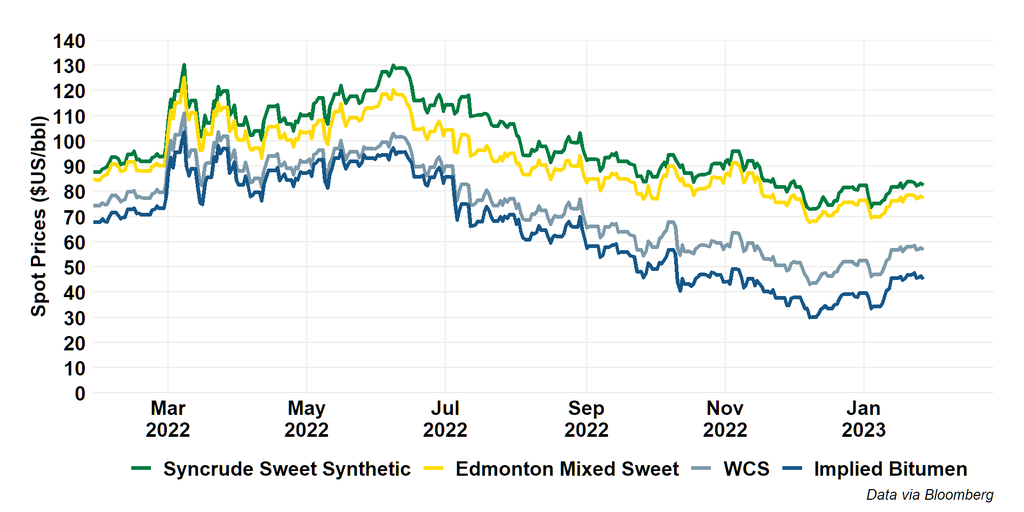

### US Crude

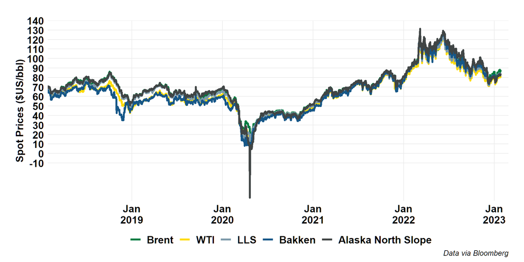

### Global Crude

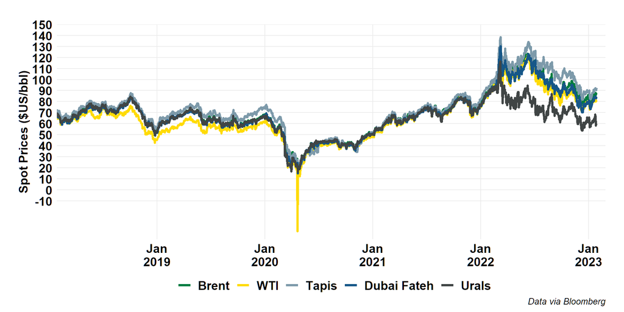

## Oil Price Differentials

### Brent-WTI

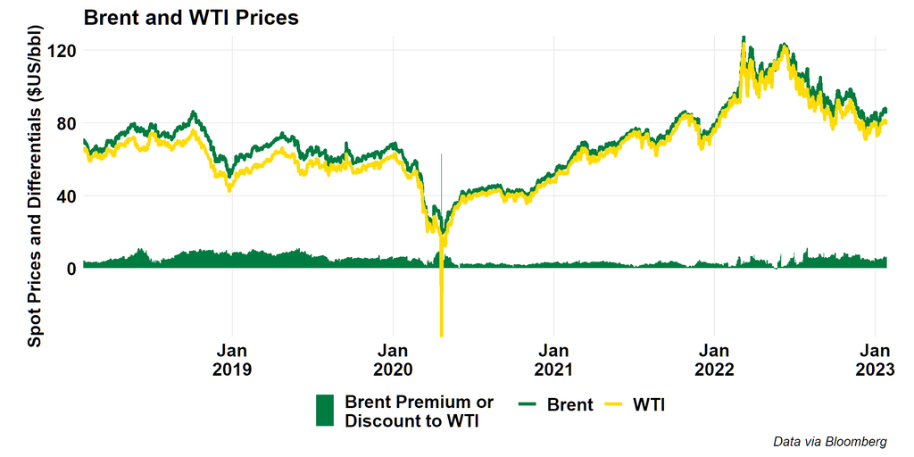

### WTI-WCS

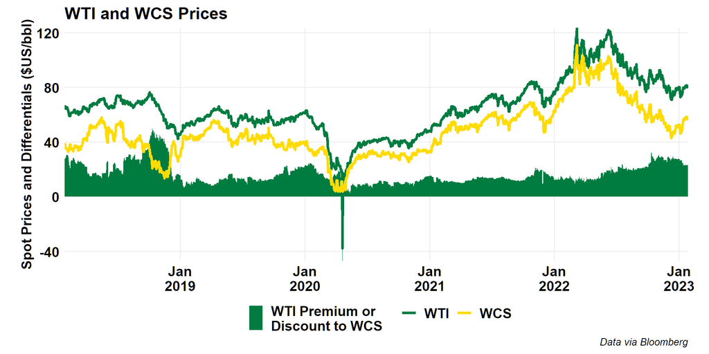

### WTI-WCS (Short)

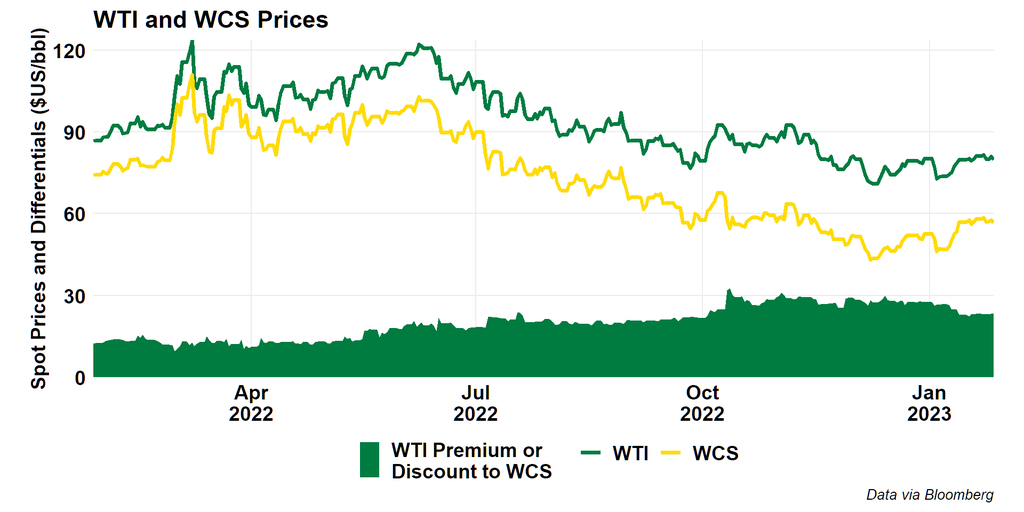

### Maya-WCS

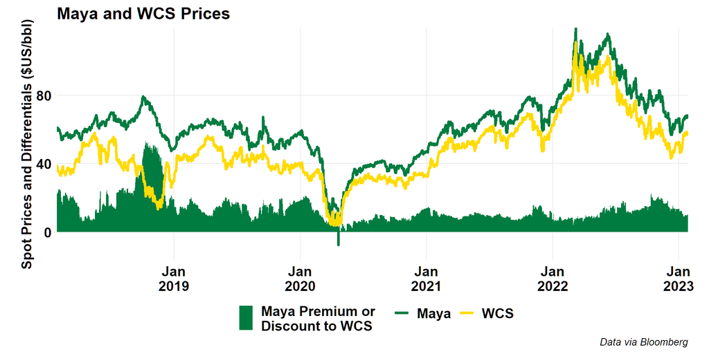

### Brent-Urals

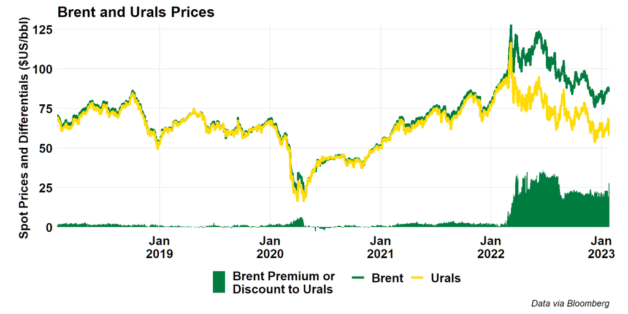

## Forward Curves

### WTI

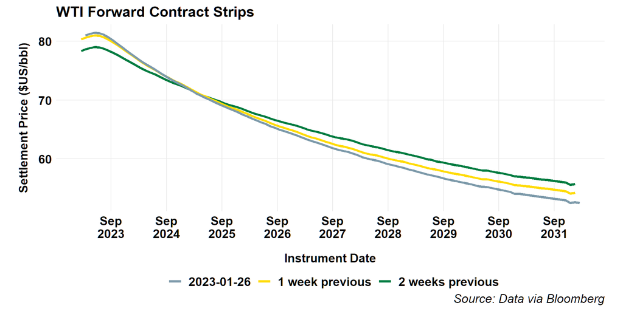

### Brent

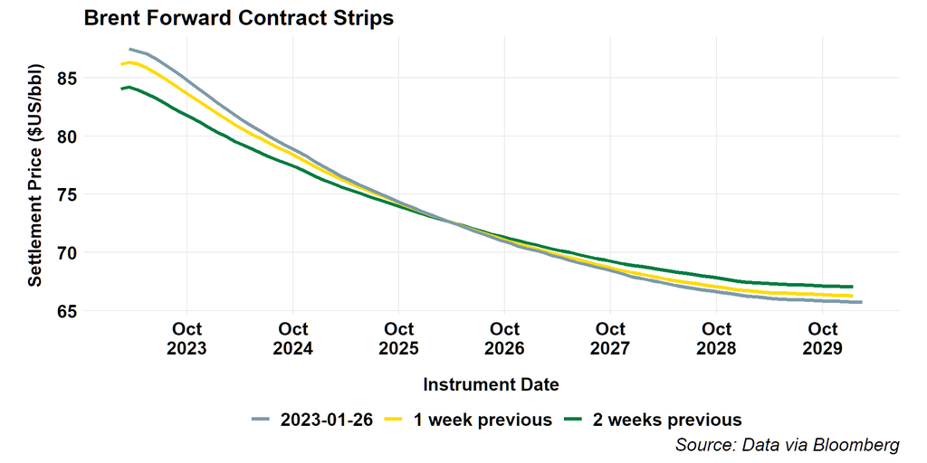

## Canadian Crude Supply and Disposition

### Canadian Production

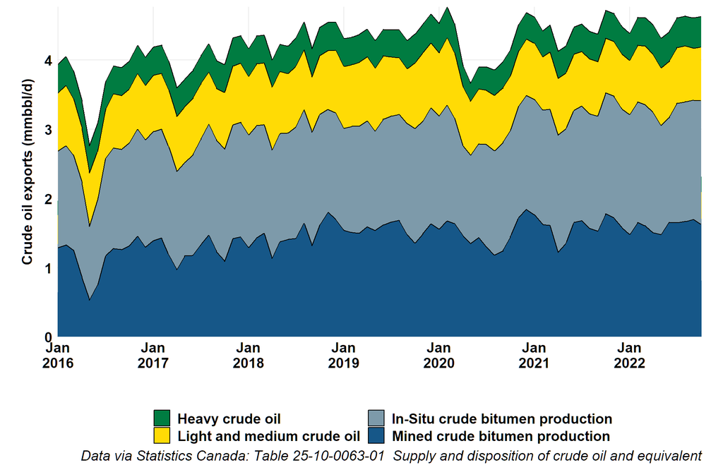

### Alberta Production

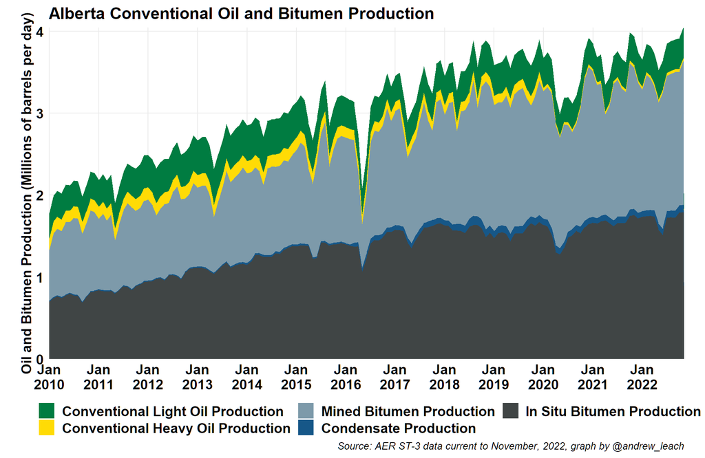

### Imports

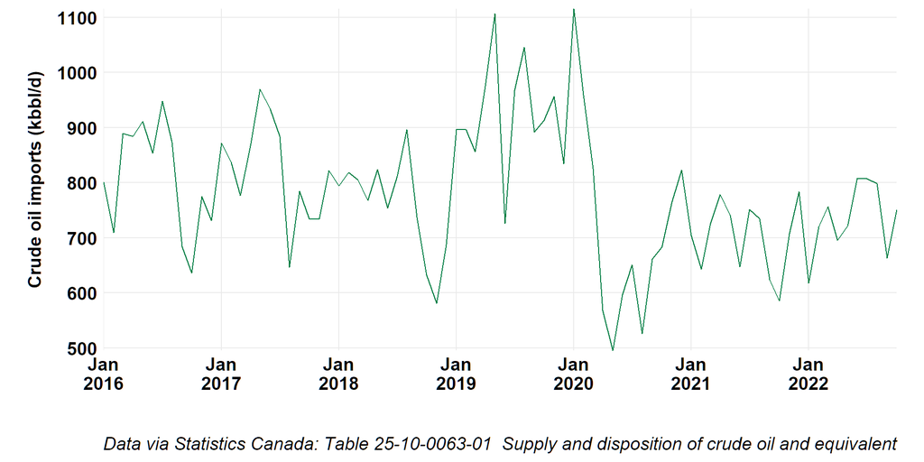

### Exports

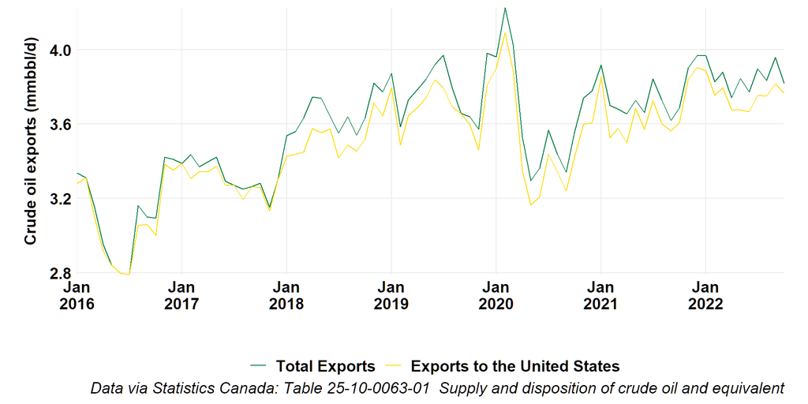

### Exports by Rail

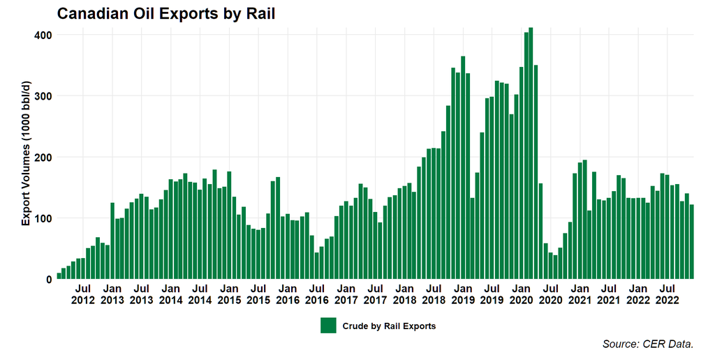

## US Oil

### Production

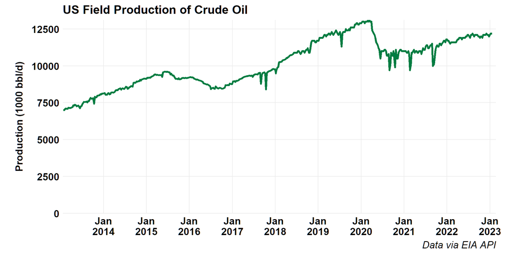

### LTO Production by Play

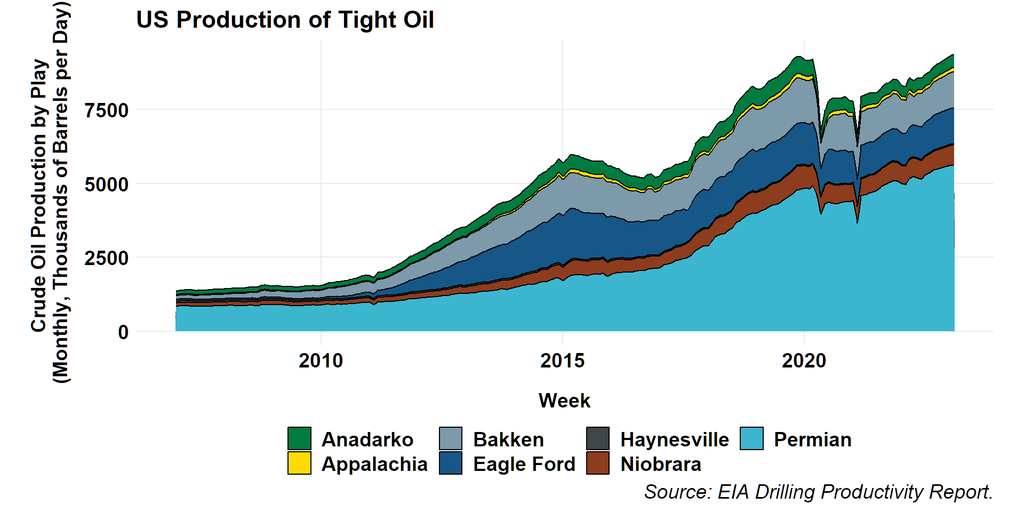

### Net Imports

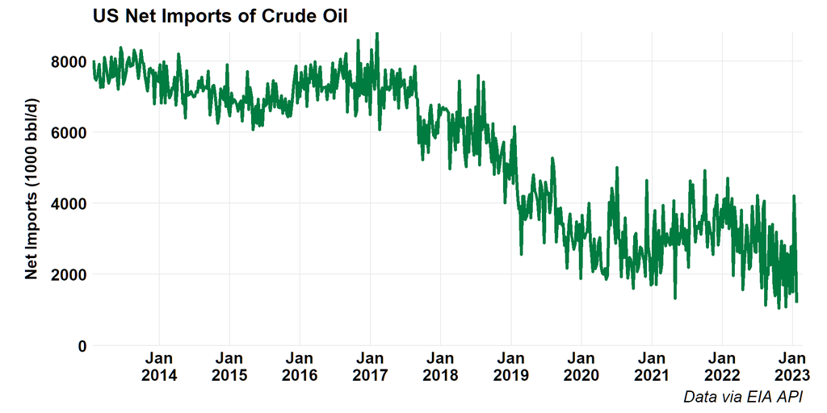

### Oil and Product Net Imports

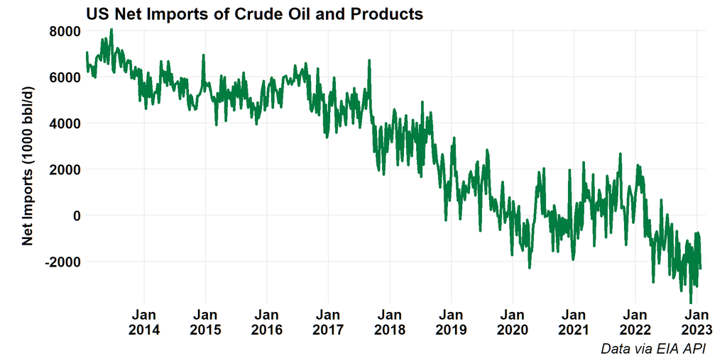

### Inventories

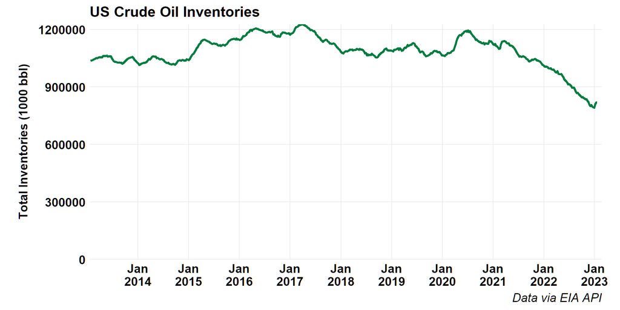

### EIA STEO Forecasts

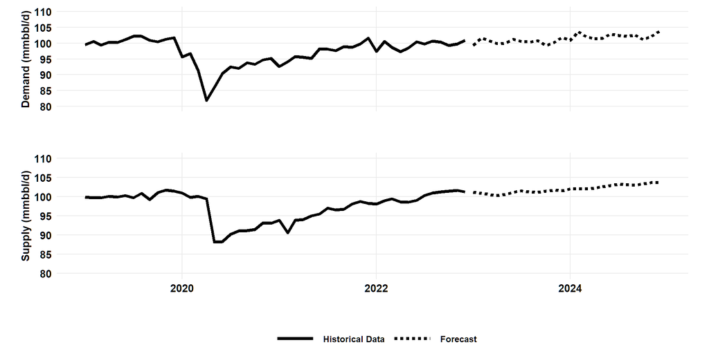

# Refined Products

## Canadian Gasoline Prices

### Map

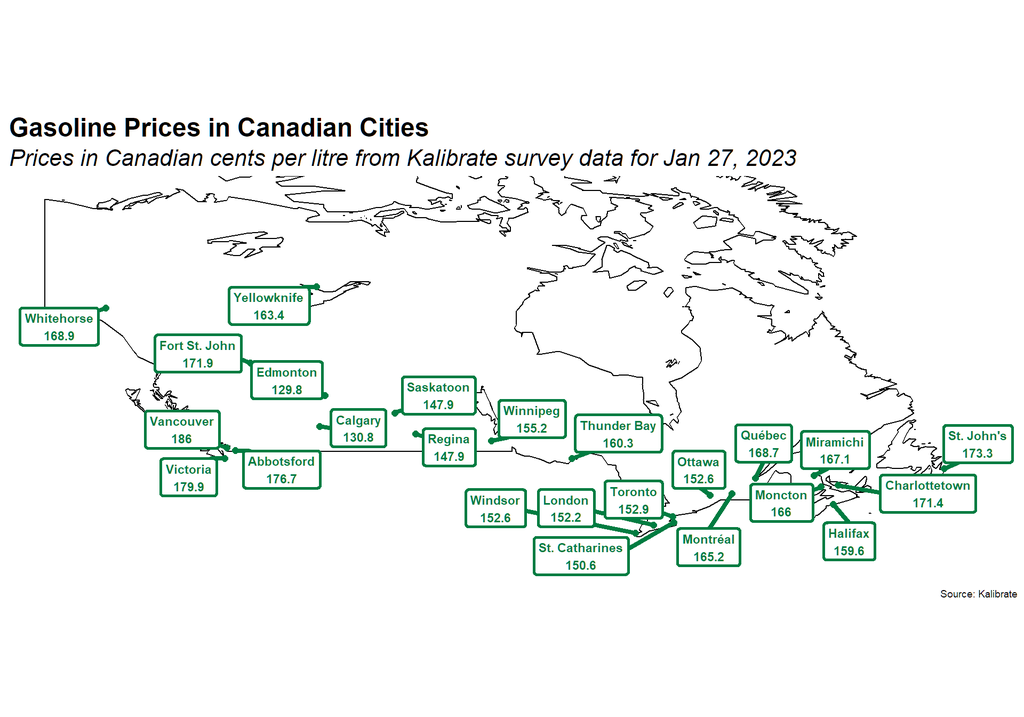

### Historic Gasoline Prices

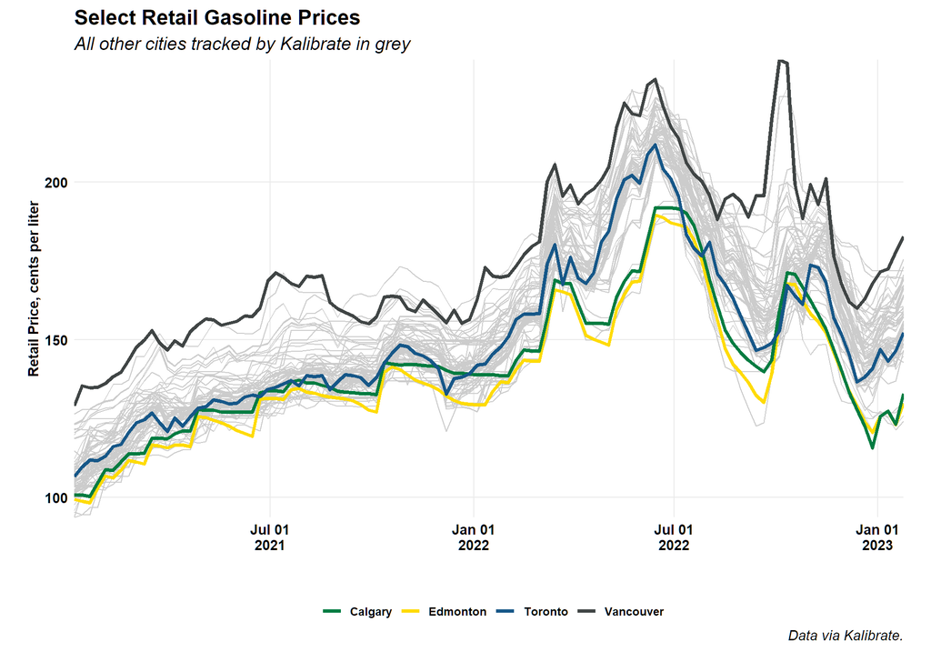

### Historic Diesel Prices

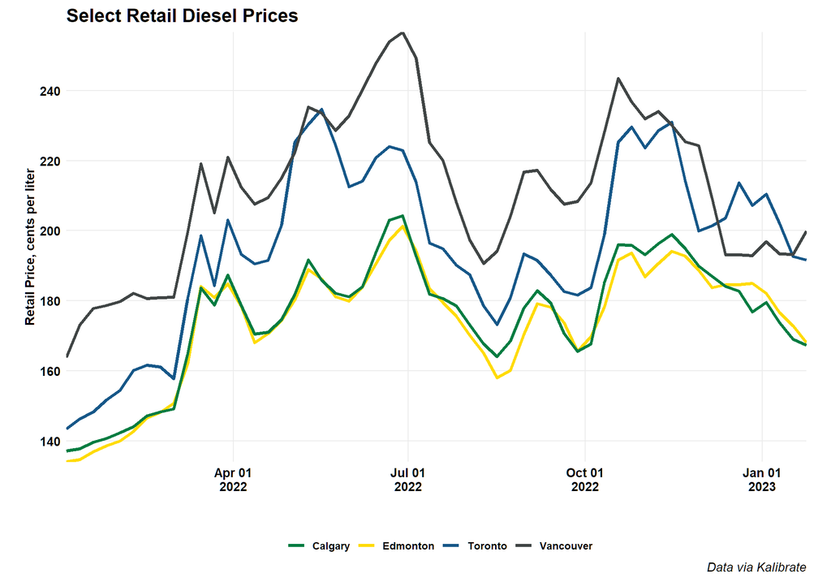

## Canadian Refinery Runs

### Canadian Refinery Runs

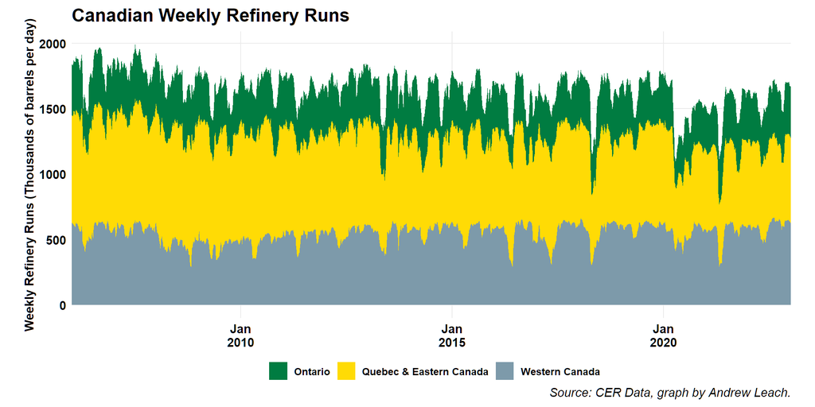

### Western Canada Refinery Runs

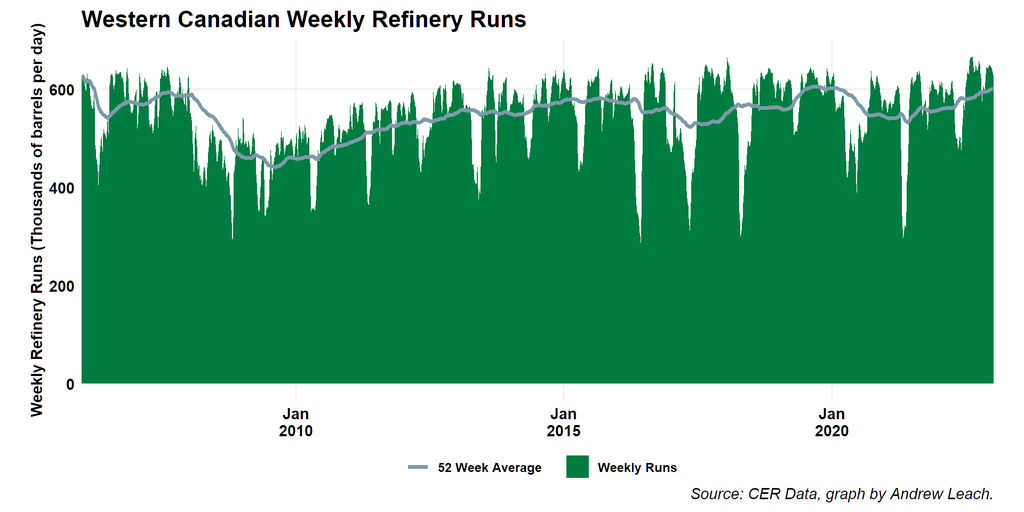